# Usando Regressão Logística, Árvores de Decisão e Boosting para predição da eleição de deputados

- Imports gerais
- Modelos
- Métricas de avaliação

```python
%%capture
!pip install imblearn scipy sklearn numpy
```

```python
%%capture
# coding: utf-8
import pandas as pd
import numpy as np
import itertools
from matplotlib import pyplot as plt
from scipy.stats import normaltest
from sklearn.utils import as_float_array
from sklearn.preprocessing import scale, MinMaxScaler

try:
  from google.colab import files, drive
  drive.mount('/content/drive')
except:
  pass
```

```python
%%capture
from imblearn.over_sampling import RandomOverSampler as ROS
from sklearn.model_selection import GridSearchCV, cross_validate, train_test_split
from sklearn.tree import DecisionTreeClassifier as DTC
from sklearn.linear_model import LogisticRegression as LogReg
from sklearn.svm import LinearSVC as LSVC
from sklearn.ensemble import AdaBoostClassifier, GradientBoostingClassifier
from sklearn.neighbors import KNeighborsClassifier as KNN
```

```python
%%capture
from sklearn.metrics import accuracy_score, auc, confusion_matrix
from sklearn.metrics import precision_score, recall_score, f1_score
from sklearn.model_selection import learning_curve, ShuffleSplit
```

## Classes auxiliares

Além dos imports feitos, farei também alguns que me auxiliarão a plotar os resultados das métricas de cada classificador.

```python
class MetricScores():
  def __init__(self, y_teste):
    self.y_teste = y_teste
    self.reset_df()

  def reset_df(self):
    colunas = ["Classifier", "Precision", "Recall", "Accuracy", "F-Score"]
    dic = dict((k, []) for k in colunas)
    self.metric_df = pd.DataFrame(dic)

  def get_df(self):
    return self.metric_df

  def insert_prediction(self, classifier, predicao):
    precision = precision_score(self.y_teste, predicao)
    recall = recall_score(self.y_teste, predicao)
    accuracy = accuracy_score(self.y_teste, predicao)
    fscore = f1_score(self.y_teste, predicao)

    new_row = {
        "Accuracy": accuracy, "Classifier": classifier,
        "F-Score": fscore, "Precision": precision, "Recall": recall
    }

    self.metric_df.loc[1 + self.metric_df.shape[0]] = new_row
```

## Import dos dados

Tentamos importar os dados a partir do Google Drive, já que está sendo feito no Google Colaboratory. Caso não seja possível, importa-se os dados a partir da pasta local.

```python
try:
  drv = 'drive/My Drive/CDP/'
  treino = pd.read_csv(drv + 'train_cat.csv')
  teste = pd.read_csv(drv + 'test_cat.csv')
except:
  treino = pd.read_csv('train_cat.csv')
  teste = pd.read_csv('test_cat.csv')
```

## Análise dos dados

Como analisaremos os dados de treino, é necessário criar funções que sejam reutilizáveis, para permitir que o mesmo procedimento seja realizado em novas etapas do código. Inicialmente, analisaremos a distribuição das variáveis numéricas com a função `analisa_numericas`, aplicando a normalização nos casos necessários, vistos posteriormente.

```python
# @hidden_cell
def plot_learning_curve(estimator, title, X, y, ylim=None, cv=None,
                        n_jobs=None, train_sizes=np.linspace(.1, 1.0, 5)):
    # Função importada dos exemplos do SKLearn
    plt.figure()
    plt.title(title)
    if ylim is not None:
        plt.ylim(*ylim)
    plt.xlabel(u"Training examples")
    plt.ylabel(u"Score")
    train_sizes, train_scores, test_scores = learning_curve(
        estimator, X, y, cv=cv, n_jobs=n_jobs, train_sizes=train_sizes)
    train_scores_mean = np.mean(train_scores, axis=1)
    train_scores_std = np.std(train_scores, axis=1)
    test_scores_mean = np.mean(test_scores, axis=1)
    test_scores_std = np.std(test_scores, axis=1)
    plt.grid()

    plt.fill_between(train_sizes, train_scores_mean - train_scores_std,
                     train_scores_mean + train_scores_std, alpha=0.1,
                     color="r")
    plt.fill_between(train_sizes, test_scores_mean - test_scores_std,
                     test_scores_mean + test_scores_std, alpha=0.1, color="g")
    plt.plot(train_sizes, train_scores_mean, 'o-', color="r",
             label=u"Training score")
    plt.plot(train_sizes, test_scores_mean, 'o-', color="g",
             label=u"Cross-validation score")

    plt.legend(loc="best")
    return plt
```

```python
# @hidden_cell
def plot_confusion_matrix(cm, classes, normalize=False, title='Confusion matrix',
                          cmap=plt.cm.Blues):
    # Função importada dos exemplos do SKLearn
    if normalize:
        cm = cm.astype('float') / cm.sum(axis=1)[:, np.newaxis]

    plt.imshow(cm, interpolation='nearest', cmap=cmap)
    plt.title(title)
    plt.colorbar()
    tick_marks = np.arange(len(classes))
    plt.xticks(tick_marks, classes, rotation=45)
    plt.yticks(tick_marks, classes)

    fmt = '.2f' if normalize else 'd'
    thresh = cm.max() / 2.
    for i, j in itertools.product(range(cm.shape[0]), range(cm.shape[1])):
        plt.text(j, i, format(cm[i, j], fmt),
                 horizontalalignment="center",
                 color="white" if cm[i, j] > thresh else "black")

    plt.ylabel(u'True label')
    plt.xlabel(u'Predicted label')
    plt.tight_layout()
```

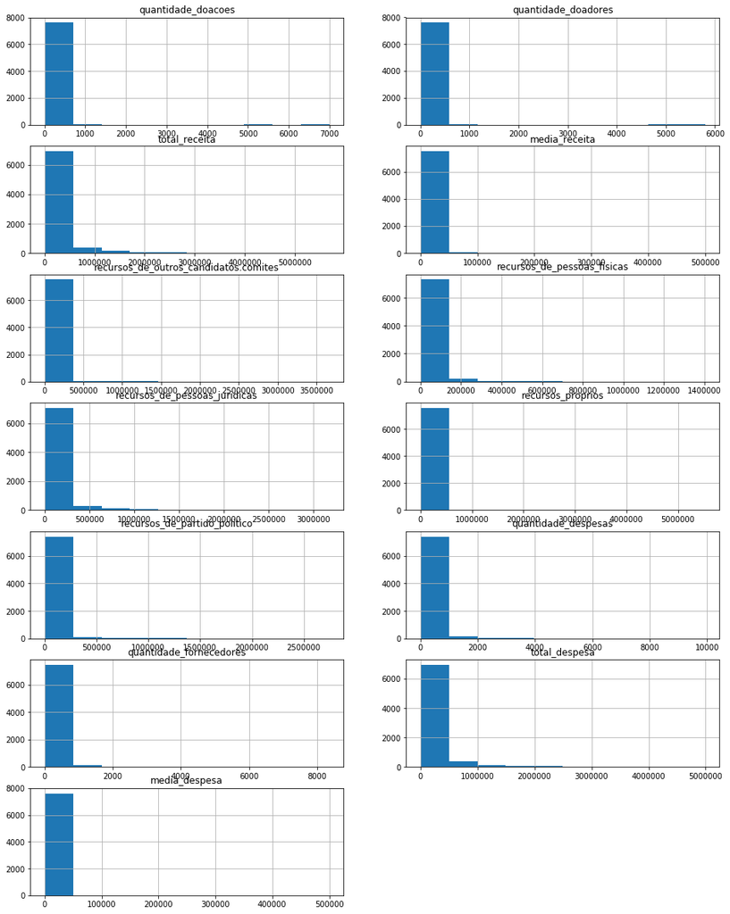

```python
def is_numerico(coluna):
  valor = coluna.ravel()[0]
  numericos = [np.float64, np.float32, np.int64]
  for n in numericos:
    if isinstance(valor, n):
      return True
  return False


def analisa_numericas(df):
  plt.figure(figsize=(16,24))
  plt.title('Análise das variáveis')

  col_numericas = []
  col_nao_normais = []
  alpha = 1e-3

  for coluna in list(df):
    if is_numerico(df[coluna]) and coluna != "ano" and coluna != "sequencial_candidato":
      col_numericas.append(coluna)
      if normaltest(df[coluna])[1] < alpha:
        col_nao_normais.append(coluna)

  for i in range(len(col_numericas)):
    coluna = col_numericas[i]
    plt.subplot(round(len(col_numericas)/2.0)+1, 2, i+1)
    plt.title(coluna)
    df[coluna].hist()
  plt.show()

  return col_nao_normais

colunas = analisa_numericas(treino)
```

## Manipulação dos Dados

A partir da análise dos gráficos acima, podemos identificar as colunas numéricas que possuem seus dados normalizados, e por isso criaremos a função `normaliza_dados`, que normaliza todas as colunas recebidas e, ao fim, repete a análise gráfica feita acima.

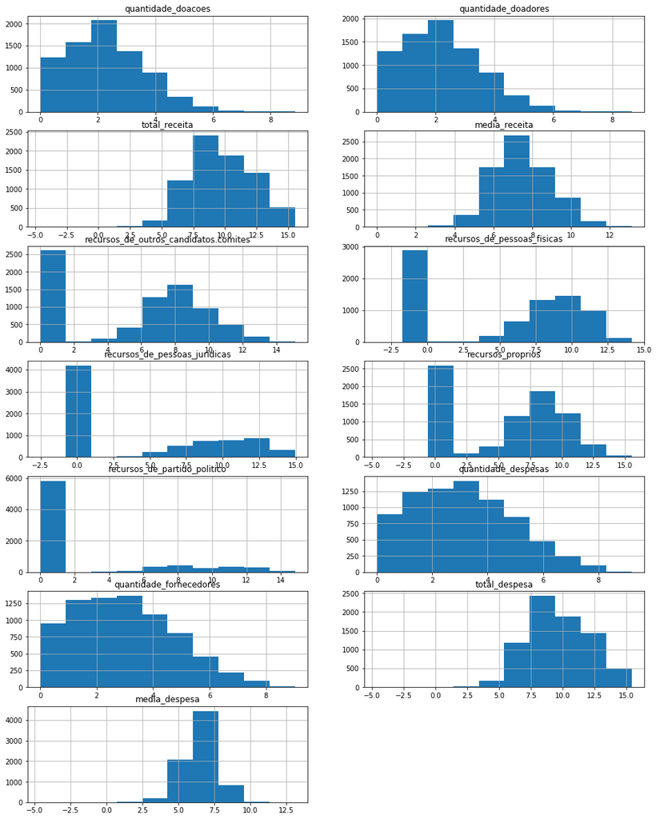

```python
def normaliza_dados(df, colunas, analisa=True):
  for col in colunas:
    temp = df[col][:].apply(np.log).values
    temp[temp == np.inf] = 0
    temp[temp == -np.inf] = 0
    temp[temp == np.nan] = 0
    df[col] = temp
  if (analisa):
    analisa_numericas(df)

  return df

treino = normaliza_dados(treino, colunas)
teste = normaliza_dados(teste, colunas, analisa = False)
```

Assim como no lab anterior, iremos descartar a coluna com os nomes dos deputados por não fazer sentido que o nome beneficie ou prejudique a eleição de um deputado.

```python
try:
  treino = treino.drop('ocupacao', axis=1)
  teste = teste.drop('ocupacao', axis=1)
  treino = treino.drop('nome', axis=1)
  teste = teste.drop('nome', axis=1)
except:
  pass
```

Em seguida, transformamos todas as colunas de fatores em variáveis dummy

```python
def transforma_fatores(df):
  fatores = ['ano', 'uf', 'partido', 'cargo', 'sexo', 'estado_civil']
  for fator in fatores:
    df = pd.concat([df, pd.get_dummies(df[fator])], axis=1)
    df = df.drop(fator, axis=1)
  return df

treino = transforma_fatores(treino)
teste = transforma_fatores(teste)
```

Como a escolaridade é um fator que, quanto maior, mais impacto, a codificamos de uma forma diferente, seguindo a função abaixo.

```python
def codifica(df, col_nome, mapa):
  nova_coluna = []

  for i, row in df.iterrows():
    nova_coluna.append(mapa[row[col_nome]])

  df[col_nome] = nova_coluna
  return df

def codifica_escolaridade(df):
  niv_escolaridade = {'LÊ E ESCREVE': 0, 'ENSINO FUNDAMENTAL INCOMPLETO': 1,
                      'ENSINO FUNDAMENTAL COMPLETO': 2,
                      'ENSINO MÉDIO INCOMPLETO': 3, 'ENSINO MÉDIO COMPLETO': 4,
                      'SUPERIOR INCOMPLETO': 5, 'SUPERIOR COMPLETO': 6 }
  return codifica(df, 'grau', niv_escolaridade)

def codifica_situacao(df):
  situacao = { 'eleito': 1, 'nao_eleito': 0 }
  return codifica(df, 'situacao', situacao)

treino = codifica_situacao(codifica_escolaridade(treino))
teste = codifica_escolaridade(teste)
```

### Padronização

Antes de iniciar o treino, é necessário padronizar os dados entre o conjunto de treino e de testes:

```python
def append_dummy_zeros(dataframe, nome_coluna):
  dataframe[nome_coluna] = pd.Series([0 for i in range(len(dataframe))])
  return dataframe

for key in teste.keys():
  try:
    treino[key]
  except:
    treino = append_dummy_zeros(treino, key)

for key in treino.keys():
  try:
    teste[key]
  except:
    if (key != 'votos'):
      teste = append_dummy_zeros(teste, key)
```

## Treinando os modelos

Para o treino das árvores, fazemos um hold-out 70/30 para dividir o conjunto de dados entre treino e teste, possibilitando a identificação dos melhores hiper-parâmetros.

```python
treino.head()
```

|  | sequencial_candidato | quantidade_doacoes | quantidade_doadores | total_receita | media_receita | recursos_de_outros_candidatos.comites | recursos_de_pessoas_fisicas | recursos_de_pessoas_juridicas | recursos_proprios | recursos_de_partido_politico | ... | PV | DEPUTADO FEDERAL | FEMININO | MASCULINO | CASADO(A) | DIVORCIADO(A) | SEPARADO(A) JUDICIALMENTE | SOLTEIRO(A) | VIÚVO(A) | 2014 |
| --- | --- | --- | --- | --- | --- | --- | --- | --- | --- | --- | --- | --- | --- | --- | --- | --- | --- | --- | --- | --- | --- |
| 0 | 10001 | 1.791759 | 1.791759 | 9.717158 | 7.925400 | 0.000000 | 9.104980 | 8.748305 | 7.170120 | 0.0 | ... | 0 | 1 | 0 | 1 | 1 | 0 | 0 | 0 | 0 | 0 |
| 1 | 10002 | 2.564949 | 2.564949 | 10.035656 | 7.470708 | 8.798606 | 9.615805 | 6.907755 | 5.303305 | 0.0 | ... | 0 | 1 | 1 | 0 | 0 | 0 | 0 | 1 | 0 | 0 |
| 2 | 10002 | 2.833213 | 2.772589 | 11.971115 | 9.137901 | 7.718685 | 10.438518 | 11.038445 | 10.993732 | 0.0 | ... | 0 | 1 | 1 | 0 | 0 | 0 | 0 | 0 | 1 | 0 |
| 3 | 10002 | 1.791759 | 1.791759 | 8.006741 | 6.214988 | 0.000000 | 7.047517 | 7.004083 | 6.620073 | 0.0 | ... | 0 | 1 | 0 | 1 | 1 | 0 | 0 | 0 | 0 | 0 |
| 4 | 10003 | 3.871201 | 3.871201 | 11.693746 | 7.822545 | 0.000000 | 10.837186 | 0.000000 | 11.141021 | 0.0 | ... | 0 | 1 | 0 | 1 | 1 | 0 | 0 | 0 | 0 | 0 |

5 rows × 85 columns

```python
x, y = treino.drop('situacao', axis=1), treino['situacao']
```

Inicialmente, como pede na questão 1 do exercício, precisamos verificar se existe desbalanceamento nos dados:

1. Há desbalanceamento das classes (isto é, uma classe tem muito mais instâncias que outra)? Em que proporção? Quais efeitos colaterais o desbalanceamento de classes pode causar no classificador? Como você poderia tratar isso? (10 pt.)

Para verificar se existe ou não desbalanceamento, verificaremos o plot da coluna y dos dados de treino:

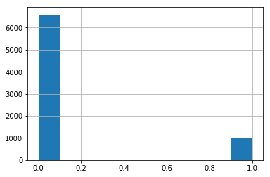

```python
y.hist()
```

Como é possível ver no gráfico acima, existe muito mais dados de deputados não eleitos do que de deputados eleitos. Para tratar esse problema existem duas possíveis técnicas: *undersampling* e *oversampling*. O *undersampling* consiste em reduzir a quantidade de amostras da categoria mais frequente à ponto de ambas categorias ficarem com quantidade similar. O *oversampling* faz justamente o contrário: seleciona amostras aleatórias dos dados que tem menor frequência e adiciona duplicatas nos dados, tentando igualar a frequência das classes.

Como retirar dados parece ser pior do que adicionar novos dados, a estratégia que eu escolhi é o oversampling:

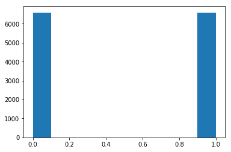

```python
ros = ROS(random_state=71)
x_res, y_res = ros.fit_resample(x, y)
plt.hist(y_res)
```

```python
df.dtypes
```

```python
x_res_df = pd.DataFrame(x_res)
x_res_df.columns = x.columns
```

```python
x, y = x_res_df, y_res
x_treino, x_teste, y_treino, y_teste = train_test_split(x, y, test_size=0.3)
cv = ShuffleSplit(n_splits=100, test_size=0.3, random_state=0)
resultados = MetricScores(y_teste)
```

```python
seq = "sequencial_candidato"
```

### Treinando a Regressão Logística

Para a regressão logística, definiremos alguns parâmetros para tunar. São eles:

- A penalidade C, que dita a força da regularização
- O número máximo de iterações

```python
c = [0.1, 0.25, 0.35, 0.50, 0.75, 1, 3, 5, 10, 25]
maxiter = [25, 50, 100, 150, 200, 300]
iteracoes_logistica = [c, maxiter]
```

Em seguida, tunamos o modelo com os parâmetros definidos acima

```python
%%capture
best_logistica = None
for ci, m in itertools.product(*iteracoes_logistica):
  logistica = LogReg(C = ci, max_iter = m, n_jobs = -1)
  logistica.fit(x_treino.drop(seq, axis=1), y_treino)
  pred = logistica.predict(x_teste.drop(seq, axis=1))
  fscore = f1_score(y_teste, pred)

  if (best_logistica == None or best_logistica[1] < fscore):
    best_logistica = [(ci, m), fscore, pred]
```

Mesmo já tendo o fscore do melhor modelo, adicionamos e calculamos as métricas deste modelo na tabela de resultados, que servirá para comparação futura e escolha do melhor modelo - que será usado na submissão.

```python
resultados.insert_prediction("Regressão Logística", best_logistica[2])
resultados.get_df().head()
```

|  | Accuracy | Classifier | F-Score | Precision | Recall |
| --- | --- | --- | --- | --- | --- |
| 1 | 0.919404 | Regressão Logística | 0.922554 | 0.886194 | 0.962025 |

### Treinando Árvores de Decisão

Para treinar as árvores, configuramos alguns parâmetros e selecionamos os que se desempenham melhor:

- Número mínimo de elementos por folha, entre 1, 5, 10, 15, 20, 30, 50, 75, 100.
- Profundidade máxima, entre 1, 5, 10, 15, 25, 30, 50 ou sem limite.
- Número máximo de folhas, entre 50, 40, 30, 20, 10, 5 ou sem limite.
- Número máximo de features, escolhido por sqrt, log2 ou sem limite máximo.
- Número mínimo de elementos ao dividir um nó, entre 2, 5, 10, 15, 20, 25, 30.

```python
# @hidden_cell
min_elements_leaf = [1, 5, 10, 15, 20, 30, 50, 75, 100]
min_split = [2, 5, 10, 15, 20, 25, 30]
max_depth = [1, 5, 10, 15, 25, 30, 50, None]
max_leafs = [50, 40, 30, 20, 10, 5, None]
max_features = ['sqrt', 'log2', None]

iteracao = [min_elements_leaf, max_depth, max_leafs, max_features, min_split]
```

Em seguida, tendo definidos os possíveis valores dos hiper-parâmetros, podemos então treinar diferentes árvores com esses parâmetros e verificar qual o melhor entre eles:

```python
best_tree = None
for a, b, c, d, e in itertools.product(*iteracao):
  tree = DTC(max_depth=b, min_samples_leaf=a, max_leaf_nodes=c, max_features=d, min_samples_split=e)
  tree.fit(x_treino.drop(seq, axis=1), y_treino)
  pred = tree.predict(x_teste.drop(seq, axis=1))
  fscore = f1_score(y_teste, pred)
  if (best_tree == None or fscore > best_tree[1]):
    best_tree = [(a,b,c,d,e), fscore, pred]
```

```
<module 'matplotlib.pyplot' from '/anaconda2/lib/python2.7/site-packages/matplotlib/pyplot.pyc'>
```

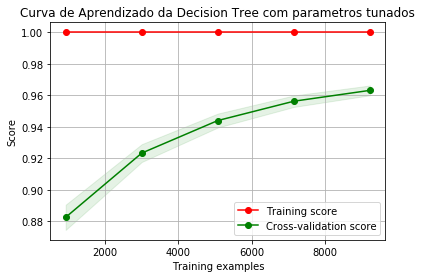

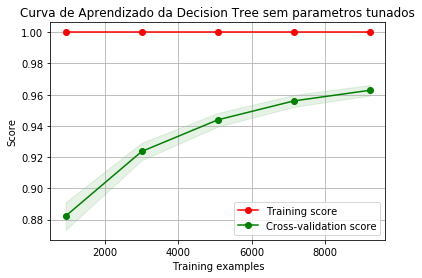

```python
# @hidden_cell
estimator = DTC(
    max_depth=best_tree[0][1],
    min_samples_leaf=best_tree[0][0],
    max_leaf_nodes=best_tree[0][2],
    max_features=best_tree[0][3],
    min_samples_split=best_tree[0][4]
)
title = 'Curva de Aprendizado da Decision Tree com parametros tunados'
plot_learning_curve(estimator, title, x.drop(seq, axis=1), y, cv=cv, n_jobs=-1)

estimator = DTC()
title = 'Curva de Aprendizado da Decision Tree sem parametros tunados'
plot_learning_curve(estimator, title, x.drop(seq, axis=1), y, cv=cv, n_jobs=-1)
```

```python
acc = accuracy_score(y_teste, best_tree[2], normalize = False)
prec = precision_score(y_teste, best_tree[2])
recall = recall_score(y_teste, best_tree[2])

resultados.insert_prediction("Árvore de Decisão Tunada", best_tree[2])

arvore_simples = DTC()
arvore_simples.fit(x_treino.drop(seq, axis=1), y_treino)
pred_n = arvore_simples.predict(x_teste.drop(seq, axis=1))

resultados.insert_prediction("Árvore de Decisão Não-Tunada", pred_n)
```

```python
resultados.get_df().head()
```

|  | Accuracy | Classifier | F-Score | Precision | Recall |
| --- | --- | --- | --- | --- | --- |
| 1 | 0.919404 | Regressão Logística | 0.922554 | 0.886194 | 0.962025 |
| 2 | 0.964376 | Árvore de Decisão Tunada | 0.965500 | 0.934186 | 0.998987 |
| 3 | 0.966145 | Árvore de Decisão Não-Tunada | 0.967157 | 0.937292 | 0.998987 |

```python
# @hidden_cell
def filtra_none(valor):
  if valor is None:
    return "Sem limite maximo"
  return str(valor)
tree_params = [filtra_none(v) for v in best_tree[0]]

print("Os parametros tunados que resultaram no melhor F-Score sao:")
print("Número minimo de elementos por folha: %s," % tree_params[0])
print("Profundidade Maxima: %s," % tree_params[1])
print("Maximo de folhas: %s," % tree_params[2])
print("Maximo de features: %s," % tree_params[3])
print("Manimo de elementos para divisao: %s." % tree_params[4])
```

```
Os parametros tunados que resultaram no melhor F-Score sao:
Número minimo de elementos por folha: 1,
Profundidade Maxima: 50,
Maximo de folhas: Sem limite maximo,
Maximo de features: Sem limite maximo,
Manimo de elementos para divisao: 2.
```

Ainda na Árvore de decisão, é possível observarmos o confusion plot, tendo uma noção de quantos foram classificados como falsos positivos ou falsos negativos:

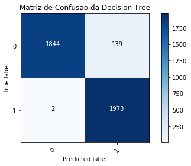

```python
matriz_arv = confusion_matrix(y_teste, best_tree[2])
np.set_printoptions(precision=2)
plt.figure()
plot_confusion_matrix(matriz_arv, classes=[0, 1],
                      title='Matriz de Confusao da Decision Tree')
```

### Treinando o classificador KNN

Inicialmente, definimos os possíveis valores para os hiper-parâmetros do KNN:

```python
# @hidden_cell
n_neighbors = [1, 2, 5, 7, 10, 15, 20, 30]
distance = [1, 2]

iteracao_knn = [n_neighbors, distance]
```

Tendo os hiper-parâmetros definidos, identificamos o melhor deles:

```python
best_knn = None
for a, b in itertools.product(*iteracao_knn):
  knn = KNN(n_neighbors = a, p = b)
  knn.fit(x_treino.drop(seq, axis=1), y_treino)
  pred = knn.predict(x_teste.drop(seq, axis=1))
  fscore = f1_score(y_teste, pred)

  if (best_knn == None or best_knn[1] < fscore):
    best_knn = [(a, b), fscore, pred]
```

```
<module 'matplotlib.pyplot' from '/anaconda2/lib/python2.7/site-packages/matplotlib/pyplot.pyc'>
```

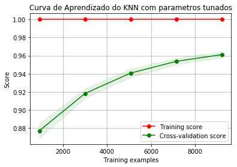

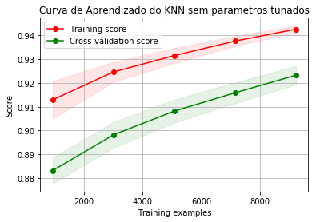

```python
# @hidden_cell
estimator = KNN(n_neighbors=best_knn[0][0], p=best_knn[0][1])
title = 'Curva de Aprendizado do KNN com parametros tunados'
plot_learning_curve(estimator, title, x.drop(seq, axis=1), y, cv=cv, n_jobs=-1)

estimator = KNN()
title = 'Curva de Aprendizado do KNN sem parametros tunados'
plot_learning_curve(estimator, title, x.drop(seq, axis=1), y, cv=cv, n_jobs=-1)
```

[figure not shown]

```python
matriz_knn = confusion_matrix(y_teste, best_knn[2])
np.set_printoptions(precision=2)
plt.figure()
plot_confusion_matrix(matriz_arv, classes=[0, 1],
                      title='Matriz de Confusao do KNN')
```

```python
resultados.insert_prediction("KNN Tunado", best_knn[2])

knn_n = KNN()
knn_n.fit(x_treino.drop(seq, axis=1), y_treino)
y_knn = knn_n.predict(x_teste.drop(seq, axis=1))

resultados.insert_prediction("KNN não Tunado", y_knn)
```

```python
# @hidden_cell
print("A melhor distancia foi de %d. O p escolhido foi: %d." % best_knn[0])
```

```
A melhor distancia foi de 1. O p escolhido foi: 1.
```

```python
resultados.get_df()
```

|  | Accuracy | Classifier | F-Score | Precision | Recall |
| --- | --- | --- | --- | --- | --- |
| 1 | 0.919404 | Regressão Logística | 0.922554 | 0.886194 | 0.962025 |
| 2 | 0.964376 | Árvore de Decisão Tunada | 0.965500 | 0.934186 | 0.998987 |
| 3 | 0.966145 | Árvore de Decisão Não-Tunada | 0.967157 | 0.937292 | 0.998987 |
| 4 | 0.961344 | KNN Tunado | 0.962710 | 0.928102 | 1.000000 |
| 5 | 0.914098 | KNN não Tunado | 0.918504 | 0.872098 | 0.970127 |

### Treinando o AdaBoost

Para treinar o AdaBoost, escolheremos um modelo de classificação fraco: uma árvore de decisão com áltura máxima sendo 1. Isso força a simplicidade do modelo e ajuda o algoritmo de boosting por ser um classificador fraco. Além disso, se define o hiper-parâmetro T, que será o número máximo de estimadores, através do tuning.

```python
simple = DTC(max_depth=1)
Ts = [1, 5, 15, 30, 50, 75, 100, 150, 200, 300]
algorithms = ['SAMME', 'SAMME.R']
iteracao_ada = [Ts, algorithms]
```

```python
best_ada = None
for t, alg in itertools.product(*iteracao_ada):
  ada = AdaBoostClassifier(simple, n_estimators=t, algorithm=alg)
  ada.fit(x_treino.drop(seq, axis=1), y_treino)
  pred = ada.predict(x_teste.drop(seq, axis=1))
  fscore = f1_score(y_teste, pred)

  if (best_ada == None or best_ada[1] < fscore):
    best_ada = [(t, alg), fscore, pred]
```

```
<module 'matplotlib.pyplot' from '/anaconda2/lib/python2.7/site-packages/matplotlib/pyplot.pyc'>
```

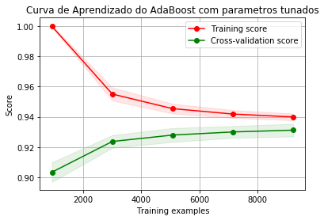

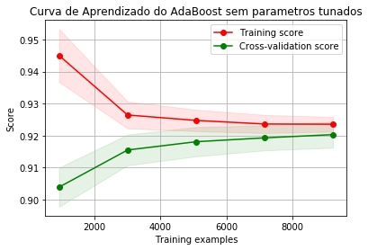

```python
# @hidden_cell
estimator = AdaBoostClassifier(simple,
                               n_estimators=best_ada[0][0],
                               algorithm=best_ada[0][1])
title = 'Curva de Aprendizado do AdaBoost com parametros tunados'
plot_learning_curve(estimator, title, x.drop(seq, axis=1), y, cv=cv, n_jobs=-1)

estimator = AdaBoostClassifier(simple)
title = 'Curva de Aprendizado do AdaBoost sem parametros tunados'
plot_learning_curve(estimator, title, x.drop(seq, axis=1), y, cv=cv, n_jobs=-1)
```

```python
acc_ada = accuracy_score(y_teste, best_ada[2], normalize = False)
prec_ada = precision_score(y_teste, best_ada[2])
recall_ada = recall_score(y_teste, best_ada[2])

resultados.insert_prediction("AdaBoost Tunado", best_ada[2])

ada_n = AdaBoostClassifier(simple)
ada_n.fit(x_treino.drop(seq, axis=1), y_treino)
y_ada = ada_n.predict(x_teste.drop(seq, axis=1))

resultados.insert_prediction("AdaBoost nao Tunado", y_ada)
```

```python
# @hidden_cell
print("O melhor numero de parametros foi de %d. O algoritmo escolhido foi: %s." % best_ada[0])
```

```
O melhor numero de parametros foi de 300. O algoritmo escolhido foi: SAMME.R.
```

```python
resultados.get_df()
```

|  | Accuracy | Classifier | F-Score | Precision | Recall |
| --- | --- | --- | --- | --- | --- |
| 1 | 0.919404 | Regressão Logística | 0.922554 | 0.886194 | 0.962025 |
| 2 | 0.964376 | Árvore de Decisão Tunada | 0.965500 | 0.934186 | 0.998987 |
| 3 | 0.966145 | Árvore de Decisão Não-Tunada | 0.967157 | 0.937292 | 0.998987 |
| 4 | 0.961344 | KNN Tunado | 0.962710 | 0.928102 | 1.000000 |
| 5 | 0.914098 | KNN não Tunado | 0.918504 | 0.872098 | 0.970127 |
| 6 | 0.927741 | AdaBoost Tunado | 0.929902 | 0.901188 | 0.960506 |
| 7 | 0.914603 | AdaBoost nao Tunado | 0.917521 | 0.885539 | 0.951899 |

## Stacking

```python
stack_df = pd.DataFrame()
stack_df['Decision Tree'] = best_tree[2]
stack_df['KNN'] = best_knn[2]
stack_df['AdaBoost'] = best_ada[2]
stack_df['Logistic Regression'] = best_logistica[2]
```

```python
stack_logistic = LogReg(C = best_logistica[0][0], max_iter = best_logistica[0][1], n_jobs = -1)
stack_logistic.fit(x_treino.drop(seq, axis=1), y_treino)
logistic_pred = stack_logistic.predict(x.drop(seq, axis=1))
```

```python
stack_tree = DTC(
    max_depth=best_tree[0][1],
    min_samples_leaf=best_tree[0][0],
    max_leaf_nodes=best_tree[0][2],
    max_features=best_tree[0][3],
    min_samples_split=best_tree[0][4]
)
stack_tree.fit(x_treino.drop(seq, axis=1), y_treino)
tree_pred = stack_tree.predict(x.drop(seq, axis=1))
```

```python
stack_knn = KNN(n_neighbors=best_knn[0][0], p=best_knn[0][1])
stack_knn.fit(x_treino.drop(seq, axis=1), y_treino)
knn_pred = stack_knn.predict(x.drop(seq, axis=1))
```

```python
stack_ada = AdaBoostClassifier(simple,
                               n_estimators=best_ada[0][0],
                               algorithm=best_ada[0][1])
stack_ada.fit(x_treino.drop(seq, axis=1), y_treino)
ada_pred = stack_ada.predict(x.drop(seq, axis=1))
```

```python
xstack = pd.DataFrame()
xstack['Decision Tree'] = tree_pred
xstack['KNN'] = knn_pred
xstack['AdaBoost'] = ada_pred
xstack['Logistic Regression'] = logistic_pred
```

```python
stacking = DTC()
stacking.fit(stack_df, y_teste)
y_stck = stacking.predict(xstack)
```

```python
resultado_stack = MetricScores(y)
resultado_stack.insert_prediction("Stack", y_stck)
resultado_stack.get_df().head()
```

|  | Accuracy | Classifier | F-Score | Precision | Recall |
| --- | --- | --- | --- | --- | --- |
| 1 | 0.994466 | Stack | 0.994495 | 0.989347 | 0.999697 |

Por fim, aplicaremos os classificadores ao conjunto de testes, e submeteremos no Kaggle

```python
teste = teste.drop('situacao', axis=1)
tree_test = stack_tree.predict(teste.drop(seq, axis=1))
ada_test = stack_ada.predict(teste.drop(seq, axis=1))
knn_test = stack_knn.predict(teste.drop(seq, axis=1))
logistic_test = stack_logistic.predict(teste.drop(seq, axis=1))
```

```python
teste_stack = pd.DataFrame()
teste_stack['Decision Tree'] = tree_test
teste_stack['KNN'] = knn_test
teste_stack['AdaBoost'] = ada_test
teste_stack['Logistic Regression'] = logistic_test
```

```python
final = stacking.predict(teste_stack)
```

```python
def save_df(dataframe, valores_preditos):
  output = pd.DataFrame()
  mapa = { 0: 'nao_eleito', 1: 'eleito'}
  output['ID'] = teste['sequencial_candidato']
  output['Predicted'] = [mapa[v] for v in valores_preditos]
  output.to_csv('submissao.csv', index=False)
  files.download('submissao.csv')
```

```python
save_df(teste, final)
```